# Supervised learning: Regression 1

Ana Martins

October 2022

## Introduction

```r
library(ISLR)
library(MASS)
library(tidyverse)
```

## Regression in `R`

1. **Create a linear model object called `lm_ses` using the formula `medv ~ lstat` and the `Boston` dataset.**

```r
lm_ses <- lm(data = Boston, formula = medv ~ lstat)
lm_ses
```

```
##
## Call:
## lm(formula = medv ~ lstat, data = Boston)
##
## Coefficients:
## (Intercept)        lstat
##       34.55        -0.95
```

2. **Use the function `coef()` to extract the intercept and slope from the `lm_ses` object. Interpret the slope coefficient.**

```r
coef(lm_ses)
```

```
## (Intercept)       lstat
##  34.5538409  -0.9500494
```

The median value of owner-occupied homes in $1000s goes down as the lower status of the population goes up.

3. **Use `summary()` to get a summary of the `lm_ses` object. What do you see? You can use the help file `?summary.lm`.**

```r
summary(lm_ses)
```

```
##
## Call:
## lm(formula = medv ~ lstat, data = Boston)
##
## Residuals:
##     Min      1Q  Median      3Q     Max
## -15.168  -3.990  -1.318   2.034  24.500
##
## Coefficients:
##             Estimate Std. Error t value Pr(>|t|)
## (Intercept) 34.55384    0.56263   61.41   <2e-16 ***
## lstat       -0.95005    0.03873  -24.53   <2e-16 ***
## ---
## Signif. codes:  0 '***' 0.001 '**' 0.01 '*' 0.05 '.' 0.1 ' ' 1
##
## Residual standard error: 6.216 on 504 degrees of freedom
## Multiple R-squared:  0.5441, Adjusted R-squared:  0.5432
## F-statistic: 601.6 on 1 and 504 DF,  p-value: < 2.2e-16
```

4. **Save the predicted y values to a variable called `y_pred`**

```r
y_pred <- predict(lm_ses)
y_pred
```

```
##          1          2          3          4          5          6          7
## 29.8225951 25.8703898 30.7251420 31.7606958 29.4900778 29.6040837 22.7447274
##          8          9         10         11         12         13         14
## 16.3603958  6.1188637 18.3079969 15.1253316 21.9466860 19.6285655 26.7064332
##         15         16         17         18         19         20         21
## 24.8063345 26.5069229 28.3025161 20.6166169 23.4477639 23.8372842 14.5838035
##         22         23         24         25         26         27         28
## 21.4146583 16.7689170 15.6668597 19.0680364 18.8685260 20.4836100 18.1369880
##         29         30         31         32         33         34         35
## 22.3932092 23.1722496 13.0827255 22.1651973  8.2279733 17.1204352 15.2298370
##         36         37         38         39         40         41         42
## 25.3573631 23.7137778 26.2219080 24.9298409 30.4496277 32.6727432 29.9556020
##         43         44         45         46         47         48         49
## 29.0340541 27.4854737 25.4808696 24.8538370 21.1106425 16.6929130  5.2828203
##         50         51         52         53         54         55         56
## 19.1630413 21.7756771 25.5948755 29.5375803 26.5449248 20.4931104 29.9841035
##         57         58         59         60         61         62         63
## 29.0720561 30.8011459 28.0365023 25.7943858 22.0606919 20.8351282 28.1600087
##         64         65         66         67         68         69         70
## 25.5283720 26.9059436 30.1171104 24.8253355 26.8584411 22.1176948 26.2029071
##         71         72         73         74         75         76         77
## 28.1695092 25.1673533 29.3095684 27.3904688 28.1125063 26.0603997 23.1817501
##         78         79         80         81         82         83         84
## 24.7968340 22.8302319 25.9083918 29.5280798 27.6944845 28.1695092 27.4189702
##         85         86         87         88         89         90         91
## 25.4143661 28.3500186 22.3362062 26.5354243 29.3285694 29.1385596 26.1839061
##         92         93         94         95         96         97         98
## 26.7634362 26.8014382 28.6540344 24.4928182 28.2360127 23.7802812 30.5541331
##         99        100        101        102        103        104        105
## 31.1621647 28.6730354 25.6043760 27.2669623 24.4548162 21.7851776 22.8397323
##        106        107        108        109        110        111        112
## 18.9065280 16.8259199 21.1676455 22.8967353 19.7805734 22.2031993 24.9013394
##        113        114        115        116        117        118        119
## 19.1535409 18.3174974 24.6258251 19.5810631 23.1152467 24.7683325 19.9515823
##        120        121        122        123        124        125        126
## 21.6236692 20.9016317 20.9966366 17.5194560 10.4130868 17.8519732 20.4836100
##        127        128        129        130        131        132        133
##  8.6554955 18.2224925 19.9325813 17.1299357 22.5832190 22.9062358 23.9892921
##        134        135        136        137        138        139        140
## 20.2745991 18.1084866 18.4410038 18.4980068 20.6926208 14.2987887 17.0159298
```

[output cut: 91 more lines]

```
## 17.3294461 16.4934027 18.4600048 19.1345399 20.5881154 18.9540305 20.6356178
##        463        464        465        466        467        468        469
## 21.2626504 24.7778330 21.9941884 21.1296435 18.2604945 14.2987887 17.3294461
##        470        471        472        473        474        475        476
## 20.5311124 19.0775369 22.3267057 20.9111322 23.4762654 17.3199456 11.6576515
##        477        478        479        480        481        482        483
## 16.8069190 10.8881115 17.4244510 22.0986939 24.3503108 27.2004589 27.8939949
##        484        485        486        487        488        489        490
## 24.6543266 21.8801825 24.5023187 20.3221016 23.6757758 17.3959496 11.7811579
##        491        492        493        494        495        496        497
##  6.3563761 17.3864491 21.8706820 23.1437481 21.6426702 17.8329723 14.4697975
##        498        499        500        501        502        503        504
## 21.1581450 22.2792032 20.2080956 20.9396336 25.3668636 25.9273927 29.1955625
##        505        506
## 28.3975211 27.0674520
```

5. **Create a scatter plot with `y_pred` mapped to the x position and the true y value (`Boston$medv`) mapped to the y value. What do you see? What would this plot look like if the fit were perfect?**

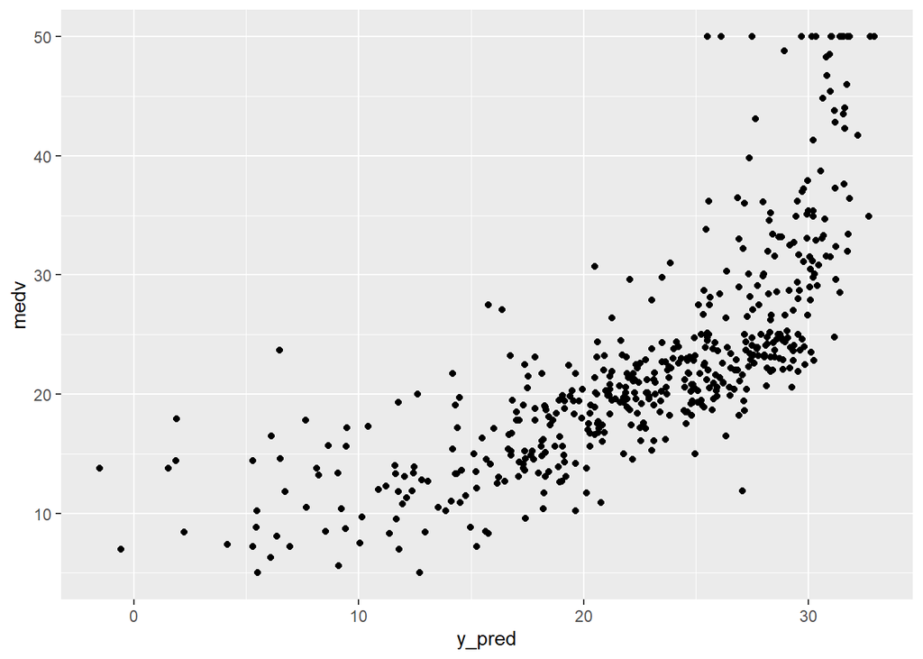

```r
ggplot() +
  geom_point(data = Boston, mapping = aes(x = y_pred, y = medv))
```

If the fit were perfect the plot would be a straight line on y = x.

6. **Use the `seq()` function to generate a sequence of 1000 equally spaced values from 0 to 40. Store this vector in a data frame with (`data.frame()` or `tibble()`) as its column name `lstat`. Name the data frame `pred_dat`.**

```r
pred_data <- data.frame(lstat = seq(0, 40, length.out = 1000))
pred_data
```

```
##            lstat
## 1     0.00000000
## 2     0.04004004
## 3     0.08008008
## 4     0.12012012
## 5     0.16016016
## 6     0.20020020
## 7     0.24024024
## 8     0.28028028
## 9     0.32032032
## 10    0.36036036
## 11    0.40040040
## 12    0.44044044
## 13    0.48048048
## 14    0.52052052
```

[output cut: 986 more lines]

7. **Use the newly created data frame as the `newdata` argument to a `predict()` call for `lm_ses`. Store it in a variable named `y_pred_new`.**

```r
y_pred_new <- predict(lm_ses, newdata = pred_data)
y_pred_new
```

```
##           1           2           3           4           5           6
## 34.55384088 34.51580087 34.47776085 34.43972084 34.40168082 34.36364081
##           7           8           9          10          11          12
## 34.32560079 34.28756078 34.24952077 34.21148075 34.17344074 34.13540072
##          13          14          15          16          17          18
## 34.09736071 34.05932070 34.02128068 33.98324067 33.94520065 33.90716064
##          19          20          21          22          23          24
## 33.86912062 33.83108061 33.79304060 33.75500058 33.71696057 33.67892055
##          25          26          27          28          29          30
## 33.64088054 33.60284053 33.56480051 33.52676050 33.48872048 33.45068047
##          31          32          33          34          35          36
## 33.41264045 33.37460044 33.33656043 33.29852041 33.26048040 33.22244038
##          37          38          39          40          41          42
## 33.18440037 33.14636036 33.10832034 33.07028033 33.03224031 32.99420030
##          43          44          45          46          47          48
## 32.95616028 32.91812027 32.88008026 32.84204024 32.80400023 32.76596021
##          49          50          51          52          53          54
## 32.72792020 32.68988019 32.65184017 32.61380016 32.57576014 32.53772013
##          55          56          57          58          59          60
## 32.49968011 32.46164010 32.42360009 32.38556007 32.34752006 32.30948004
##          61          62          63          64          65          66
## 32.27144003 32.23340002 32.19536000 32.15731999 32.11927997 32.08123996
##          67          68          69          70          71          72
## 32.04319994 32.00515993 31.96711992 31.92907990 31.89103989 31.85299987
##          73          74          75          76          77          78
## 31.81495986 31.77691985 31.73887983 31.70083982 31.66279980 31.62475979
##          79          80          81          82          83          84
## 31.58671977 31.54867976 31.51063975 31.47259973 31.43455972 31.39651970
##          85          86          87          88          89          90
## 31.35847969 31.32043968 31.28239966 31.24435965 31.20631963 31.16827962
##          91          92          93          94          95          96
## 31.13023960 31.09219959 31.05415958 31.01611956 30.97807955 30.94003953
##          97          98          99         100         101         102
## 30.90199952 30.86395951 30.82591949 30.78787948 30.74983946 30.71179945
##         103         104         105         106         107         108
## 30.67375943 30.63571942 30.59767941 30.55963939 30.52159938 30.48355936
##         109         110         111         112         113         114
## 30.44551935 30.40747934 30.36943932 30.33139931 30.29335929 30.25531928
##         115         116         117         118         119         120
## 30.21727926 30.17923925 30.14119924 30.10315922 30.06511921 30.02707919
```

[output cut: 279 more lines]

```
## -1.73633263 -1.77437265 -1.81241266 -1.85045268 -1.88849269 -1.92653270
##         961         962         963         964         965         966
## -1.96457272 -2.00261273 -2.04065275 -2.07869276 -2.11673278 -2.15477279
##         967         968         969         970         971         972
## -2.19281280 -2.23085282 -2.26889283 -2.30693285 -2.34497286 -2.38301287
##         973         974         975         976         977         978
## -2.42105289 -2.45909290 -2.49713292 -2.53517293 -2.57321295 -2.61125296
##         979         980         981         982         983         984
## -2.64929297 -2.68733299 -2.72537300 -2.76341302 -2.80145303 -2.83949304
##         985         986         987         988         989         990
## -2.87753306 -2.91557307 -2.95361309 -2.99165310 -3.02969312 -3.06773313
##         991         992         993         994         995         996
## -3.10577314 -3.14381316 -3.18185317 -3.21989319 -3.25793320 -3.29597321
##         997         998         999        1000
## -3.33401323 -3.37205324 -3.41009326 -3.44813327
```

## Plotting lm() in `ggplot`

8. **Create a scatter plot from the `Boston` dataset with `lstat` mapped to the x position and `medv` mapped to the y position. Store the plot in an object called `p_scatter`.**

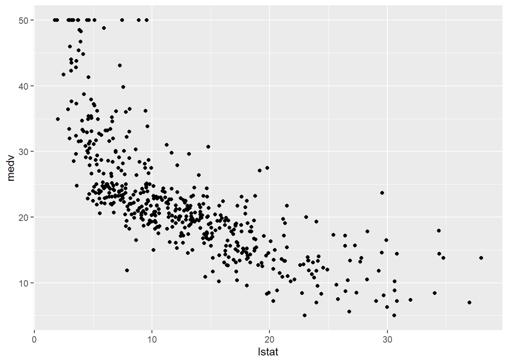

```r
p_scatter <-
  ggplot() +
  geom_point(data = Boston, mapping = aes(x = lstat, y = medv))
p_scatter
```

9. **Add the vector `y_pred_new` to the `pred_dat` data frame with the name `medv`.**

```r
pred_data <-
  pred_data %>%
  mutate(medv = y_pred_new)
pred_data
```

```
##            lstat        medv
## 1     0.00000000 34.55384088
## 2     0.04004004 34.51580087
## 3     0.08008008 34.47776085
## 4     0.12012012 34.43972084
## 5     0.16016016 34.40168082
## 6     0.20020020 34.36364081
## 7     0.24024024 34.32560079
## 8     0.28028028 34.28756078
## 9     0.32032032 34.24952077
## 10    0.36036036 34.21148075
## 11    0.40040040 34.17344074
## 12    0.44044044 34.13540072
## 13    0.48048048 34.09736071
## 14    0.52052052 34.05932070
```

[output cut: 986 more lines]

10. **Add a geom_line() to `p_scatter`, with `pred_dat` as the `data` argument. What does this line represent?**

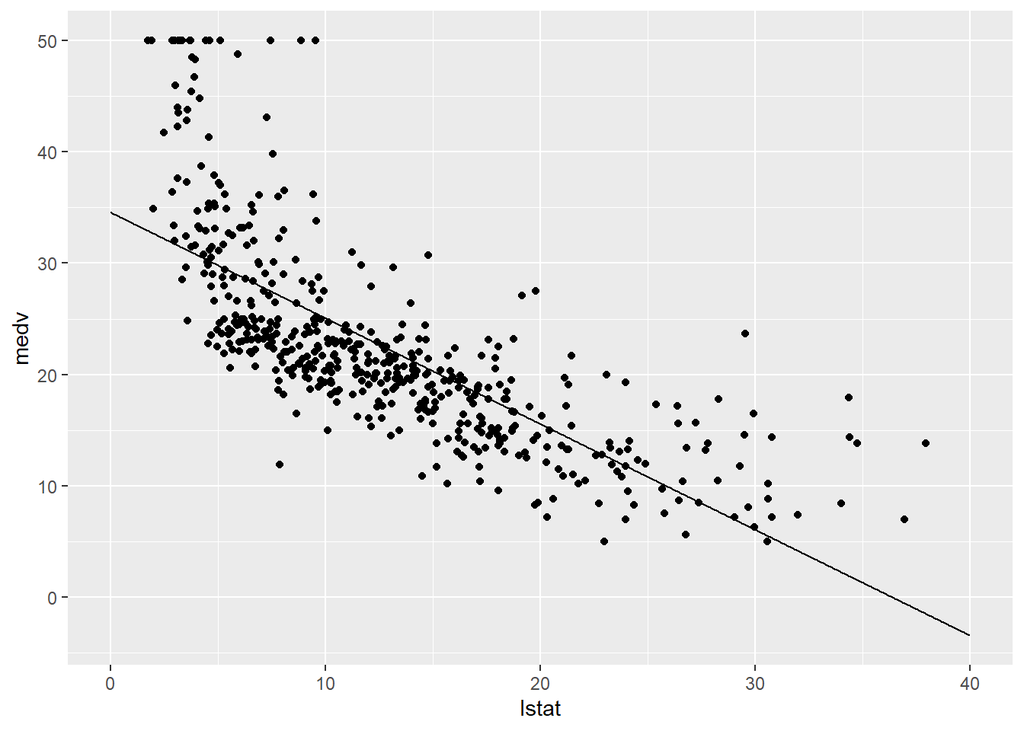

```r
p_scatter <-
  p_scatter +
  geom_line(data = pred_data, mapping = aes(x = lstat, y = medv))
p_scatter
```

The prediction for the data.

11. **The `interval` argument can be used to generate confidence or prediction intervals. Create a new object called `y_pred_95` using `predict()` (again with the `pred_dat` data) with the `interval` argument set to “confidence”. What is in this object?**

```r
y_pred_95 <- predict(lm_ses, newdata = pred_data, interval = "confidence")
y_pred_95
```

```
##              fit         lwr          upr
## 1    34.55384088 33.44845704 35.659224718
## 2    34.51580087 33.41307021 35.618531522
## 3    34.47776085 33.37768134 35.577840367
## 4    34.43972084 33.34229041 35.537151267
## 5    34.40168082 33.30689741 35.496464237
## 6    34.36364081 33.27150232 35.455779293
## 7    34.32560079 33.23610514 35.415096449
## 8    34.28756078 33.20070584 35.374415721
## 9    34.24952077 33.16530441 35.333737124
## 10   34.21148075 33.12990083 35.293060675
## 11   34.17344074 33.09449509 35.252386388
## 12   34.13540072 33.05908717 35.211714279
## 13   34.09736071 33.02367705 35.171044366
## 14   34.05932070 32.98826473 35.130376663
```

[output cut: 986 more lines]

```r
class(y_pred_95)
```

```
## [1] "matrix" "array"
```

The fitted value for various xs and the lower and upper confidence limit.

12. **Create a data frame with 4 columns: `medv`, `lstat`, `lower`, and `upper`.**

```r
df <-
  data.frame(lstat = pred_data$lstat,
             medv = y_pred_95[, 1],
             lower = y_pred_95[, 2],
             upper = y_pred_95[, 3])
df
```

```
##            lstat        medv       lower        upper
## 1     0.00000000 34.55384088 33.44845704 35.659224718
## 2     0.04004004 34.51580087 33.41307021 35.618531522
## 3     0.08008008 34.47776085 33.37768134 35.577840367
## 4     0.12012012 34.43972084 33.34229041 35.537151267
## 5     0.16016016 34.40168082 33.30689741 35.496464237
## 6     0.20020020 34.36364081 33.27150232 35.455779293
## 7     0.24024024 34.32560079 33.23610514 35.415096449
## 8     0.28028028 34.28756078 33.20070584 35.374415721
## 9     0.32032032 34.24952077 33.16530441 35.333737124
## 10    0.36036036 34.21148075 33.12990083 35.293060675
## 11    0.40040040 34.17344074 33.09449509 35.252386388
## 12    0.44044044 34.13540072 33.05908717 35.211714279
## 13    0.48048048 34.09736071 33.02367705 35.171044366
## 14    0.52052052 34.05932070 32.98826473 35.130376663
```

[output cut: 986 more lines]

13. **Add a `geom_ribbon()` to the plot with the data frame you just made. The ribbon geom requires three aesthetics: `x` (`lstat`, already mapped), `ymin` (`lower`), and `ymax` (`upper`). Add the ribbon below the `geom_line()` and the `geom_points()` of before to make sure those remain visible. Give it a nice colour and clean up the plot, too!**

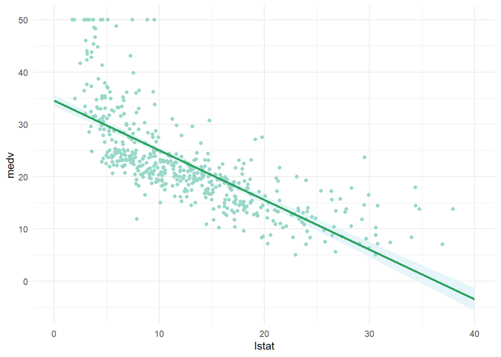

```r
ggplot(data = Boston, mapping = aes(x = lstat, y = medv)) +
  geom_ribbon(data = df, mapping = aes(ymin = lower, ymax = upper), fill = "#e5f5f9") +
  geom_point(color = "#99d8c9") +
  geom_line(data = pred_data, color = "#2ca25f", size = 1) +
  theme_minimal()
```

14. **Explain in your own words what the ribbon represents.**

The ribbon encloses all values within the confidence interval for the medv variable.

15. **Do the same thing, but now with the prediction interval instead of the confidence interval.**

```r
y_pred_int <- predict(lm_ses, newdata = pred_data, interval = "prediction")
y_pred_int
```

```
##              fit          lwr       upr
## 1    34.55384088  22.29192272 46.815759
## 2    34.51580087  22.25412160 46.777480
## 3    34.47776085  22.21631973 46.739202
## 4    34.43972084  22.17851711 46.700925
## 5    34.40168082  22.14071373 46.662648
## 6    34.36364081  22.10290960 46.624372
## 7    34.32560079  22.06510471 46.586097
## 8    34.28756078  22.02729908 46.547822
## 9    34.24952077  21.98949269 46.509549
## 10   34.21148075  21.95168554 46.471276
## 11   34.17344074  21.91387765 46.433004
## 12   34.13540072  21.87606900 46.394732
## 13   34.09736071  21.83825960 46.356462
## 14   34.05932070  21.80044945 46.318192
```

[output cut: 986 more lines]

```r
df_int <-
  data.frame(lstat = pred_data$lstat,
             medv = y_pred_int[, 1],
             lower = y_pred_int[, 2],
             upper = y_pred_int[, 3])
df_int
```

```
##            lstat        medv        lower     upper
## 1     0.00000000 34.55384088  22.29192272 46.815759
## 2     0.04004004 34.51580087  22.25412160 46.777480
## 3     0.08008008 34.47776085  22.21631973 46.739202
## 4     0.12012012 34.43972084  22.17851711 46.700925
## 5     0.16016016 34.40168082  22.14071373 46.662648
## 6     0.20020020 34.36364081  22.10290960 46.624372
## 7     0.24024024 34.32560079  22.06510471 46.586097
## 8     0.28028028 34.28756078  22.02729908 46.547822
## 9     0.32032032 34.24952077  21.98949269 46.509549
## 10    0.36036036 34.21148075  21.95168554 46.471276
## 11    0.40040040 34.17344074  21.91387765 46.433004
## 12    0.44044044 34.13540072  21.87606900 46.394732
## 13    0.48048048 34.09736071  21.83825960 46.356462
## 14    0.52052052 34.05932070  21.80044945 46.318192
```

[output cut: 986 more lines]

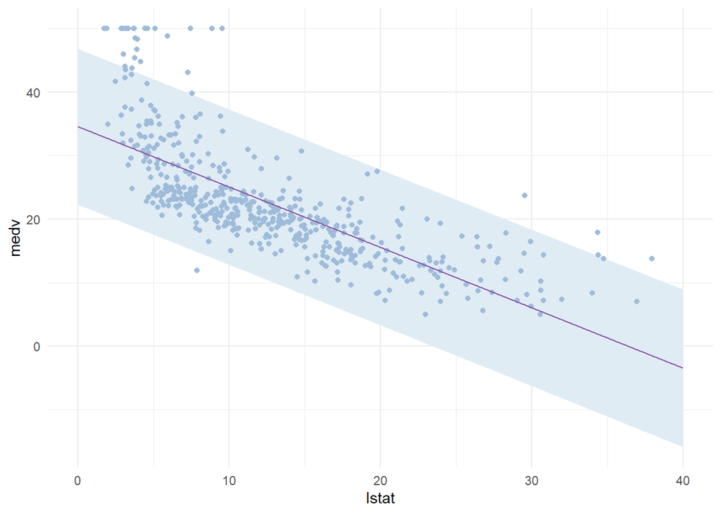

```r
ggplot(data = Boston, mapping = aes(x = lstat, y = medv)) +
  geom_ribbon(data = df_int, mapping = aes(ymin = lower, ymax = upper), fill = "#e0ecf4") +
  geom_point(color = "#9ebcda") +
  geom_line(data = pred_data, color = "#8856a7") +
  theme_minimal()
```

## Mean square error

16. **Write a function called `mse()` that takes in two vectors: true y values and predicted y values, and which outputs the mean square error.**

```r
mse <- function(y_true, y_pred) {
  mean((y_true - y_pred)^2)
}
```

17. **Make sure your `mse()` function works correctly by running the following code.**

```r
mse(1:10, 10:1)
```

```
## [1] 33
```

18. **Calculate the mean square error of the `lm_ses` model. Use the `medv` column as `y_true` and use the `predict()` method to generate `y_pred`.**

```r
mse(Boston$medv, predict(lm_ses))
```

```
## [1] 38.48297
```

## Train-validation-test split

19. **The `Boston` dataset has 506 observations. Use `c()` and `rep()` to create a vector with 253 times the word “train”, 152 times the word “validation”, and 101 times the word “test”. Call this vector `splits`.**

```r
splits <- c(rep("train", 253), rep("validation", 152), rep("test", 101))
```

20. **Use the function `sample()` to randomly order this vector and add it to the `Boston` dataset using `mutate()`. Assign the newly created dataset to a variable called `boston_master`.**

```r
boston_master <-
  Boston %>%
  mutate(splits = sample(splits))
```

21. **Now use `filter()` to create a training, validation, and test set from the `boston_master` data. Call these datasets `boston_train`, `boston_valid`, and `boston_test`.**

```r
boston_train <-
  boston_master %>%
  filter(splits == "train")

boston_valid <-
  boston_master %>%
  filter(splits == "validation")

boston_test <-
  boston_master %>%
  filter(splits == "test")
```

22. **Train a linear regression model called `model_1` using the training dataset. Use the formula `medv ~ lstat` like in the first `lm()` exercise. Use `summary()` to check that this object is as you expect.**

```r
model_1 <- lm(medv ~ lstat, data = boston_train)
summary(model_1)
```

```
##
## Call:
## lm(formula = medv ~ lstat, data = boston_train)
##
## Residuals:
##     Min      1Q  Median      3Q     Max
## -10.537  -4.693  -1.885   2.102  23.894
##
## Coefficients:
##             Estimate Std. Error t value Pr(>|t|)
## (Intercept) 36.19256    0.87025   41.59   <2e-16 ***
## lstat       -1.05842    0.06263  -16.90   <2e-16 ***
## ---
## Signif. codes:  0 '***' 0.001 '**' 0.01 '*' 0.05 '.' 0.1 ' ' 1
##
## Residual standard error: 6.828 on 251 degrees of freedom
## Multiple R-squared:  0.5322, Adjusted R-squared:  0.5303
## F-statistic: 285.6 on 1 and 251 DF,  p-value: < 2.2e-16
```

23. **Calculate the MSE with this object. Save this value as `model_1_mse_train`.**

```r
model_1_mse_train <- mse(y_true = boston_train$medv, y_pred = predict(model_1))
model_1_mse_train
```

```
## [1] 46.24827
```

24. **Now calculate the MSE on the validation set and assign it to variable `model_1_mse_valid`. Hint: use the `newdata` argument in `predict()`.**

```r
model_1_mse_valid <- mse(y_true = boston_valid$medv,
                         y_pred = predict(model_1, newdata = boston_valid))
model_1_mse_valid
```

```
## [1] 34.82704
```

25. **Create a second model `model_2` for the train data which includes `age` and `tax` as predictors. Calculate the train and validation MSE.**

```r
model_2 <- lm("medv ~ lstat + age + tax", data = boston_train)
typeof(model_2)
```

```
## [1] "list"
```

```r
model_2_mse_train <- mse(y_true = boston_train$medv, y_pred = predict(model_2))
model_2_mse_valid <- mse(y_true = boston_valid$medv,
                         y_pred = predict(model_2, newdata = boston_valid))
```

27. **Calculate the test MSE for the model of your choice in the previous question. What does this number tell you?**

```r
model_2_mse_test <- mse(y_true = boston_test$medv, y_pred = predict(model_2, newdata = boston_test))
```

The estimate for the expected amount of error when predicting the median value of a not previously seen town in Boston when using this model is given by the sqrt of `model_2_mse_test`.

## Programming exercise: cross-validation

28. **Create a function that performs k-fold cross-validation for linear models.**

```r
kfoldcv <- function(formula, dataset, k) {

  y <- unlist(strsplit(formula, " "))[1]

  if (nrow(dataset)%%k == 0) {
    splits <- rep(c(1:k), each=(nrow(dataset)/k))
  } else {
    for (i in 1:(k/2)) {
      if (nrow(dataset)%%(k+i) == 0){
        splits <- c(rep(c(1:k), each=(nrow(dataset)/k)), 1:i)
      }
    }
  }

  data_master <-
    dataset %>%
    mutate(splits = sample(splits))

  sum_mse = 0

  for (i in 1:k) {
    model <-
      data_master %>%
      filter(splits != i) %>%
      lm(formula = formula, data = .)
    test_data <-
      data_master %>%
      filter(splits == i)
    sum_mse = sum_mse + mse(y_true = dataset[, c(y)], y_pred = predict(model, newdata = test_data))
  }

  sum_mse / k

}
```

29. **Use your function to perform 9-fold cross validation with a linear model with as its formula `medv ~ lstat + age + tax`. Compare it to a model with as formula `medv ~ lstat + I(lstat^2) + age + tax`.**

```r
kfoldcv("medv ~ lstat + age + tax", Boston, 9)
```

```
## [1] 128.9267
```

```r
kfoldcv("medv ~ lstat + I(lstat^2) + age + tax", Boston, 9)
```

[output not shown]

```
## [1] 138.0334
```

I get a warning for the test and training sets not being the same length but I feel like that’s how it makes sense…